# The simplest model of logistic regression using tabulated subset data

## Model description

This simplest model describes only presence or absence of whitefish larvae $y$, not its density. Here the observational model is described as Bernoulli distribution given as:

$$y_i |m_i \sim Bernoulli(g^{-1}(m_i(x_i))),$$

where we assume logit transformation of the mean function $m(x)$

$$g(m_i(x_i))= logit(m_i(x_i)) = log\left(\frac{m_i(x_i)}{1-m_i(x_i)}\right)$$

The mean function $m(x)$ follows the logistic regression model:

$$m(x) = logit^{-1}(\alpha_0 + \alpha_1\delta_1(x_1)+ ... + \alpha_6x_6(x_1) + x_2\beta_1 + ... + x_6\beta_5).$$

In this model:

$\delta_d(x_1)=1$ if $x_1=d$ and zero otherwise, $\alpha_d \sim N(0,10)$ and $\beta_d \sim N(0,10), 0, ..., 5$

The priors are defined as:

$$\alpha_d \sim N(0,10)$$
and
$$\beta_d \sim N(0,10), d=0, ..., 5$$

The posterior distribution:

$$p(\alpha_0, \alpha_1, ..., \alpha_6, \beta_1, ... ,\beta_5 | y,x) = p(\alpha_0)p(\alpha_l) ... p(\alpha_6)p(\beta_1)...p(\beta_5)\prod_{i=1}^{n}p(y_i | \alpha_0,\alpha_1, ..., \alpha_5,\beta_1, ... ,\beta_5, x_i)$$

## Visualizing the study area and two environmental variables

We start with loading the smaller subset data (in tabular format) and visualizing the study area. First we plot the variable Distance to 20m deep water at the sampling locations. The locations of samling sites are marked in black.

```r
setwd("D:/Neli/MThesis/Ex_7_trials")

if (.Platform$OS.type != "windows") {
  if (Sys.getenv("RSTUDIO") == "1") {
    windows <- function( ... ) X11( ... )
  } else {
    windows <- dev.new
  }
}

library("rstan")
library(matrixStats)
options(mc.cores = parallel::detectCores())

library("raster")
```

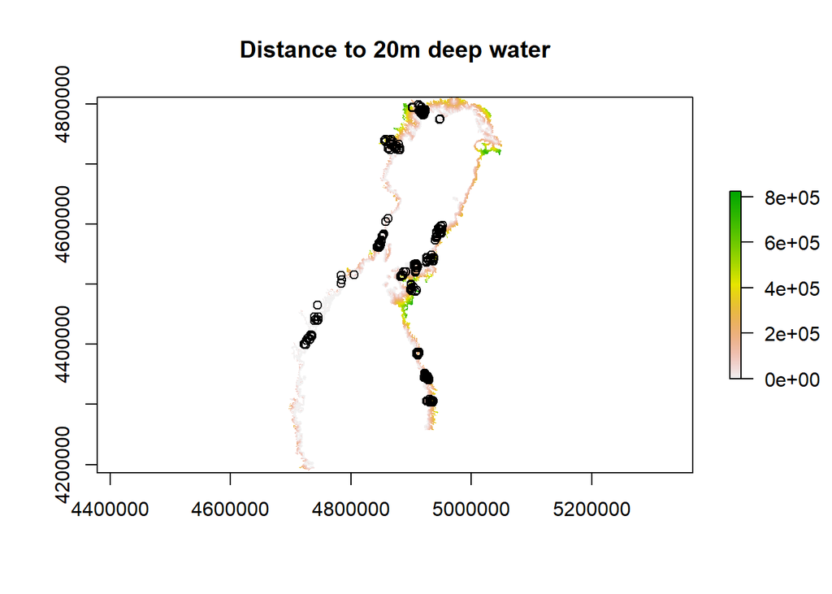

```r
library(Rcpp)
# Load the data
whitefish.dat = read.table("data_whitefish.txt", header=TRUE, sep="\t")
whitefish.raster = read.table("predraster_whitefish.txt", header=TRUE, sep="\t")

## The coordinate system in the data is ETRS89.
## This is a 3D cartesian coordinate system constructed specifically to European areas.
##  In whitefish.dat the coordinates are N_etrs89 E_etrs89
##  In whitefish.raster the coordinates are X Y

# First examine the data by plotting few of the raster layers

# Visualize few environmental covariates
e <- extent(cbind(whitefish.raster$X,whitefish.raster$Y))
r <- raster(e, ncol=length(unique(whitefish.raster$X)), nrow=length(unique(whitefish.raster$Y)))

z <- rasterize(cbind(whitefish.raster$X,whitefish.raster$Y), r, whitefish.raster$DIST20M, fun=mean)
plot(z, xlim=cbind(min(whitefish.raster$X),max(whitefish.raster$X)),
     ylim=cbind(min(whitefish.raster$Y),max(whitefish.raster$Y)), main="Distance to 20m deep water")

# Plot the locations of sampling sites
points(whitefish.dat$E_etrs89,whitefish.dat$N_etrs89)
```

The last ice cover day in 2009 at sampling locations is visualized on the next plot:

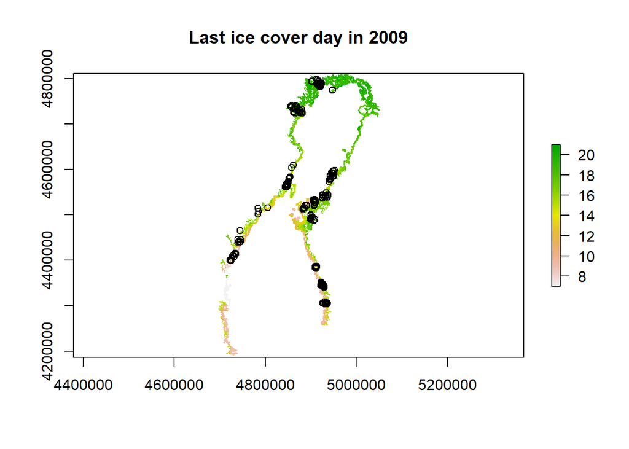

```r
# Plot Last ice cover day in 2009
z <- rasterize(cbind(whitefish.raster$X,whitefish.raster$Y), r, whitefish.raster$ICELAST09, fun=mean)
plot(z, xlim=cbind(min(whitefish.raster$X),max(whitefish.raster$X)),
     ylim=cbind(min(whitefish.raster$Y),max(whitefish.raster$Y)), main="Last ice cover day in 2009")
# Plot the locations of sampling sites
points(whitefish.dat$E_etrs89,whitefish.dat$N_etrs89)
```

## Performing logistic regression using Stan.

The environmental covariates are:

BOTTOMCLS - Bottom type classifiction, a categorical variable with the following classes: 0 = not shallow 1 = open water 2 = other 3 = sand 4 = sand/mud 5 = sand/stone

DIS_SAND - distance to sandy shore, continuous variable

FE300ME - The average fetch (opennes/exposure) over all directions, continuous variable

ICELAST09 - The last ice cover date in winter 2009-10, continuous variable

RIVERS - Influence of rivers (~weighted average distance to river mouths), continuous variable

SAL910WIN - Winter salinity in 2009-2010, continuous variable

The output variable is WHISUM - the number of whitefishes caught in sampling occasion.

In this simplest case we model only presence or absence of whitefish, because of which we transform it to 0/1 binary variable.

First we set up an standardize the data and prediction varables.

```r
# Set up data
s = as.matrix(cbind(whitefish.dat$E_etrs89,whitefish.dat$N_etrs89)) / 1000   # spatial coordinates in km
x = matrix(0,nrow=nrow(s),ncol=12)      # intercept + 6 BOTTOMCLS classes + 5 continues covariates
x[,1] = 1                             # Set the column corresponding to intercept to 1
x[whitefish.dat$BOTTOMCLS==0,2] = 1   # Set the elements corresponding to BOTTOMCLS = 0 to 1
x[whitefish.dat$BOTTOMCLS==1,3] = 1   # Set the elements corresponding to BOTTOMCLS = 1 to 1
x[whitefish.dat$BOTTOMCLS==2,4] = 1   # Set the elements corresponding to BOTTOMCLS = 2 to 1
x[whitefish.dat$BOTTOMCLS==3,5] = 1   # Set the elements corresponding to BOTTOMCLS = 3 to 1
x[whitefish.dat$BOTTOMCLS==4,6] = 1   # Set the elements corresponding to BOTTOMCLS = 4 to 1
x[whitefish.dat$BOTTOMCLS==5,7] = 1   # Set the elements corresponding to BOTTOMCLS = 5 to 1
xcont = as.matrix(cbind(whitefish.dat$DIS_SAND,
                        whitefish.dat$FE300ME,
                        whitefish.dat$ICELAST09,
                        whitefish.dat$RIVERS,
                        whitefish.dat$SAL910WIN))
stdxcont = apply(xcont, 2, sd)
mxcont = apply(xcont, 2, mean)
x[,8:12] = t( apply( t(apply(xcont,1,'-',mxcont)),1,'/',stdxcont) )    # "standardize" the continuous covariates

# End variable
#transform WHISUM to binary: 0 if 0, 1 otherwise
whitefish.dat$WHISUM[whitefish.dat$WHISUM > 0] <- 1
y = whitefish.dat$WHISUM               # number of counted fish larvae
#head(y)
#tail(y)

# Prediction variables
spred = as.matrix(cbind(whitefish.raster$X,whitefish.raster$Y)) / 1000  # spatial coordinates in km
xpred = matrix(0,nrow=nrow(spred),ncol=12)      # intercept + 6 BOTTOMCLS classes + 5 continues covariates
xpred[,1] = 1                             # Set the column corresponding to intercept to 1
xpred[whitefish.raster$BOTTOMCLS==0,2] = 1   # Set the elements corresponding to BOTTOMCLS = 0 to 1
xpred[whitefish.raster$BOTTOMCLS==1,3] = 1   # Set the elements corresponding to BOTTOMCLS = 1 to 1
xpred[whitefish.raster$BOTTOMCLS==2,4] = 1   # Set the elements corresponding to BOTTOMCLS = 2 to 1
xpred[whitefish.raster$BOTTOMCLS==3,5] = 1   # Set the elements corresponding to BOTTOMCLS = 3 to 1
xpred[whitefish.raster$BOTTOMCLS==4,6] = 1   # Set the elements corresponding to BOTTOMCLS = 4 to 1
xpred[whitefish.raster$BOTTOMCLS==5,7] = 1   # Set the elements corresponding to BOTTOMCLS = 5 to 1
xpredcont = as.matrix(cbind(whitefish.raster$DIS_SAND,
                            whitefish.raster$FE300ME,
                            whitefish.raster$ICELAST09,
                            whitefish.raster$RIVERS,
                            whitefish.raster$SAL910WIN))
xpred[,8:12] = t( apply( t(apply(xpredcont,1,'-',mxcont)),1,'/',stdxcont) )    # "standardize" the continuous covariates

dim(x)
```

```
## [1] 217  12
```

```r
length(y)
```

```
## [1] 217
```

The Stan hierarchical model of logistic regression is given in the chunk bellow. We have used y ~ bernoulli_logit((x.beta)) instead y ~ bernoulli(inv_logit(x.beta)) since the function **bernoulli_logit** is numerically stable.

```stan
data {
  int<lower=1> N; //number of observations
  int<lower=1> Dx; //number of predictors + first column = intercept alpha_0
  matrix[N,Dx] x; //covariate matrix
  int<lower=0> y[N];
}

parameters {
  vector [Dx] beta;
}

model {
  //priors for alpha and beta coefficients
  //all alpha and beta coefficients are involved in beta column vector
  //beta =[alpha0, alpha1, ..., alpha6,beta1,...,beta5]
  //Set week priors for intercept and all other covariates
  for (i in 1:Dx)
    beta[i] ~ normal(0, 10);

  //the likelihood
  //y ~ bernoulli(inv_logit(x*beta)); - does not work; not stable numercally
  y ~ bernoulli_logit((x*beta));
}
```

Next we simulate and analyze the Stan model using MCMC simulations and statistics. We start 4 initial chains and check their mixing and convergence properties.

```r
 #x = x[seq(1,217,length=60),]
 #y = y[seq(1,217,length=60)]

whitefish_dat <- list(Dx = ncol(x),
                      N = nrow(x),
                      x = x,
                      y = y)

#set initial values of the chains
#rnorm(#samples, mu,sigma)
set.seed(124)
#init1 <-list(beta=as.vector(rep(0,ncol(x))))
init1 <- list(beta=as.vector(rnorm(ncol(x),0,10)))
init2 <- list(beta=as.vector(rnorm(ncol(x),0,10)))
init3 <- list(beta=as.vector(rnorm(ncol(x),0,10)))
init4 <- list(beta=as.vector(rnorm(ncol(x),0,10)))
inits = list(init1,init2,init3,init4)

# Compile the STAN model
library(rstudioapi)
fit <- stan(file = "Log_reg_whitefish.stan", data = whitefish_dat, warmup=200,
            iter = 1000, init=inits , control = list(adapt_delta = 0.99), pars=c("beta"))
beta <- as.matrix(fit)

print(fit)
```

```
## Inference for Stan model: Log_reg_whitefish.
## 4 chains, each with iter=1000; warmup=200; thin=1;
## post-warmup draws per chain=800, total post-warmup draws=3200.
##
##             mean se_mean   sd    2.5%     25%     50%     75%   97.5% n_eff
## beta[1]     0.93    0.14 3.79   -6.60   -1.56    0.90    3.38    8.79   696
## beta[2]     0.48    0.15 3.98   -7.35   -2.10    0.47    3.10    8.54   735
## beta[3]     0.48    0.14 3.81   -7.16   -2.01    0.54    2.99    8.17   700
## beta[4]    -1.05    0.14 3.93   -8.77   -3.60   -1.05    1.56    6.82   749
## beta[5]    -0.60    0.15 3.86   -8.46   -3.14   -0.52    1.93    7.00   697
## beta[6]    -0.58    0.14 3.79   -8.43   -3.06   -0.54    1.95    6.91   691
## beta[7]     0.12    0.14 3.79   -7.69   -2.31    0.18    2.66    7.55   704
## beta[8]    -1.27    0.01 0.35   -1.97   -1.50   -1.25   -1.03   -0.61  1882
## beta[9]    -0.09    0.00 0.18   -0.44   -0.21   -0.08    0.04    0.26  1766
## beta[10]    0.05    0.01 0.23   -0.40   -0.10    0.06    0.21    0.50  1714
## beta[11]   -0.04    0.00 0.18   -0.39   -0.16   -0.04    0.08    0.31  2073
## beta[12]    0.04    0.01 0.39   -0.72   -0.23    0.05    0.31    0.81  1685
## lp__     -117.63    0.09 2.63 -123.64 -119.17 -117.29 -115.70 -113.51   944
##          Rhat
## beta[1]  1.01
## beta[2]  1.01
## beta[3]  1.01
## beta[4]  1.00
## beta[5]  1.00
## beta[6]  1.01
## beta[7]  1.01
## beta[8]  1.00
## beta[9]  1.00
## beta[10] 1.00
## beta[11] 1.00
## beta[12] 1.00
## lp__     1.01
##
## Samples were drawn using NUTS(diag_e) at Tue Mar 10 01:57:24 2020.
## For each parameter, n_eff is a crude measure of effective sample size,
## and Rhat is the potential scale reduction factor on split chains (at
## convergence, Rhat=1).
```

```r
#lp_ ->log density up to a constant
# https://www.jax.org/news-and-insights/jax-blog/2015/october/lp-in-stan-output
#log density = log likelihood of the observations conditioned on the posterior parameters: p(y | p_post).
```

We see that the potential scale reduction factor *Rhat=1* for all scalar beta estimates, as it should be for convergent multivariate distribution in the limit $n \rightarrow \infty$. The effective sample size *n_eff* is related to the precision obtained from the simulations. By one emperical rule (Gelman, Carlin, Stern, Dunson, Vehtari, and Rubin (2013). Bayesian Data Analysis, third edition. CRC Press.) $n_{eff} = 5.m$, where $m$ is twice the number of sequences, here $m=8$ and $n_{eff} = 40$. We see that here all $n_{eff} > 40$.

A summary statistics of every chain is shown bellow:

```r
summary(fit)
```

```
## $summary
##                   mean     se_mean        sd         2.5%           25%
## beta[1]     0.93005779 0.143553831 3.7878889   -6.5994845   -1.55835804
## beta[2]     0.47612363 0.146837210 3.9798587   -7.3454670   -2.09974834
## beta[3]     0.47792085 0.144040937 3.8104990   -7.1557769   -2.01045567
## beta[4]    -1.05446771 0.143390519 3.9252295   -8.7696723   -3.59841652
## beta[5]    -0.60202224 0.146180673 3.8599563   -8.4590846   -3.13891480
## beta[6]    -0.57598592 0.144361345 3.7941034   -8.4269853   -3.06378986
## beta[7]     0.12012079 0.142995511 3.7933133   -7.6871114   -2.31438189
## beta[8]    -1.26768248 0.008142142 0.3532333   -1.9650028   -1.50151571
## beta[9]    -0.08639468 0.004310511 0.1811326   -0.4449529   -0.20770680
## beta[10]    0.05374187 0.005448898 0.2256001   -0.4020074   -0.09701791
## beta[11]   -0.04189437 0.003907883 0.1779450   -0.3895333   -0.16056413
## beta[12]    0.04488307 0.009574134 0.3930370   -0.7244571   -0.23085919
## lp__     -117.62639469 0.085535583 2.6286898 -123.6405488 -119.17227884
##                    50%           75%        97.5%     n_eff      Rhat
## beta[1]     0.89918005    3.37791677    8.7899152  696.2495 1.0054687
## beta[2]     0.47180779    3.10118427    8.5417124  734.6205 1.0058134
## beta[3]     0.54092795    2.98814979    8.1701436  699.8288 1.0054025
## beta[4]    -1.05176038    1.55682298    6.8209671  749.3578 1.0047400
## beta[5]    -0.51636995    1.93358512    7.0034202  697.2441 1.0045962
## beta[6]    -0.54060622    1.94782110    6.9143008  690.7430 1.0053538
## beta[7]     0.17605997    2.66011539    7.5487306  703.7082 1.0056901
## beta[8]    -1.25293994   -1.02503977   -0.6059835 1882.1140 0.9997874
## beta[9]    -0.08460255    0.04134827    0.2606185 1765.7765 1.0020743
## beta[10]    0.05907418    0.20542496    0.5015585 1714.1998 1.0000486
## beta[11]   -0.04244255    0.07645574    0.3094642 2073.4268 1.0020145
## beta[12]    0.04511241    0.30989812    0.8083027 1685.2636 1.0003563
## lp__     -117.28811238 -115.70392191 -113.5063977  944.4632 1.0053898
##
## $c_summary
## , , chains = chain:1
##
##           stats
## parameter           mean        sd         2.5%           25%           50%
##   beta[1]     0.76952394 3.8344176   -7.2841792   -1.58016243    0.66993124
##   beta[2]     0.60756408 4.0389912   -7.1996267   -2.01618764    0.67705915
##   beta[3]     0.63966886 3.8447634   -6.8409274   -1.78901156    0.71427768
##   beta[4]    -0.86388260 3.8976964   -8.4384897   -3.25895364   -0.83404458
##   beta[5]    -0.39628275 3.9091366   -8.1144588   -2.82339671   -0.23493505
```

[output cut: 107 more lines]

```
##           stats
## parameter            75%        97.5%
##   beta[1]     3.91650281    9.2329003
##   beta[2]     2.64188427    7.6001153
##   beta[3]     2.79062095    7.2573924
##   beta[4]     1.32309471    6.1628704
##   beta[5]     1.64896403    6.5209176
##   beta[6]     1.66375834    6.1476386
##   beta[7]     2.35443123    6.7586358
##   beta[8]    -1.02089728   -0.5619723
##   beta[9]     0.05092646    0.2733400
##   beta[10]    0.22365804    0.5615229
##   beta[11]    0.09130373    0.2931806
##   beta[12]    0.33154011    0.8310722
##   lp__     -115.78388082 -113.7733456
```

We continue to analyse MCMC convergence by visual analysis of mixing and stationarity via taceplots of all $\beta$ parameters.

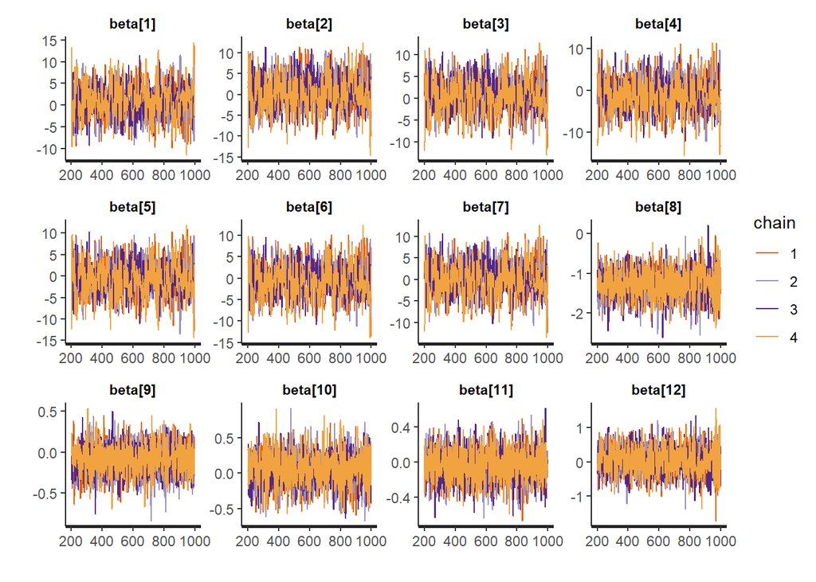

```r
#parameter's matrix:
b <- as.matrix(fit)
beta<-b[,-13]
colnames(beta)<-c("alpha_0","alpha_1","alpha_2","alpha_3","alpha_4","alpha_5","alpha_6","beta_1","beta_2","beta_3","beta_4","beta_5")

stan_trace(fit, pars = c("beta"))
```

These plots show good mixing of all chains and therefore we can conclude that the convergence is achieved.

Posterior densities and histograms of all estimated $\beta$ are:

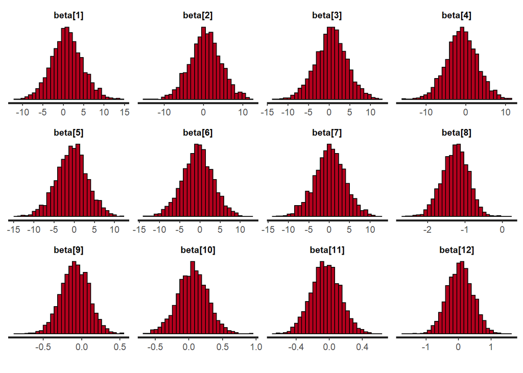

```r
#posterior densties and histograms
stan_hist(fit, pars='beta', bins=30)
```

The credible intervals of all $\beta$ estimates are:

```
## ci_level: 0.5 (50% intervals)
```

```
## outer_level: 0.95 (95% intervals)
```

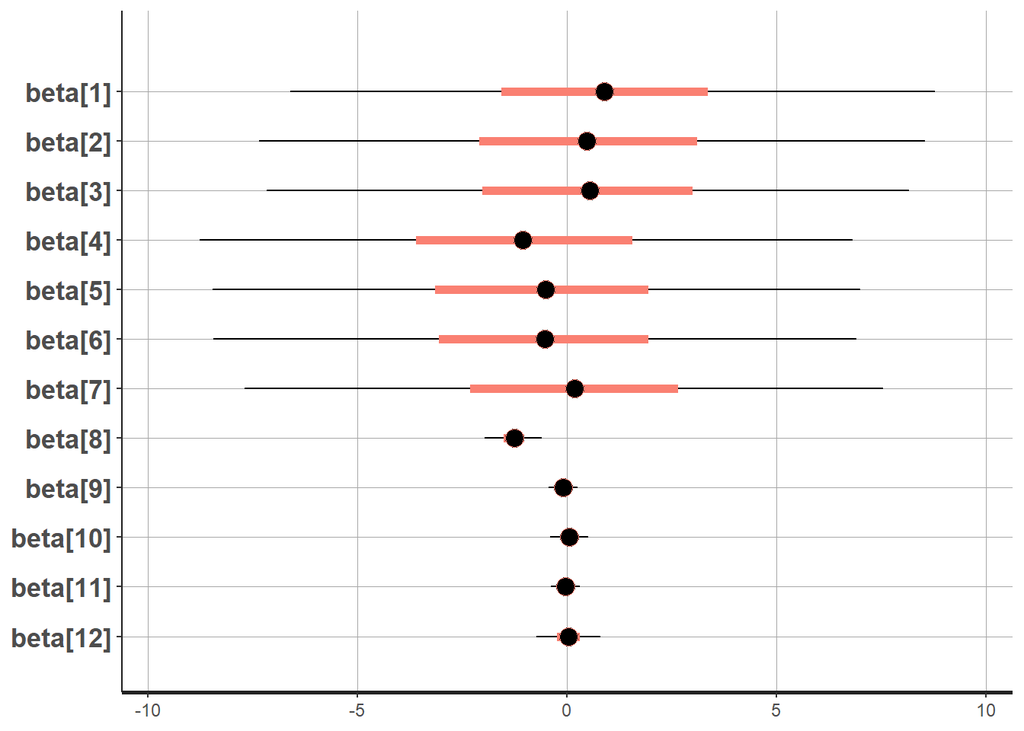

```r
#show credible intervals
plot(fit, show_density = FALSE, ci_level = 0.5, outer_level = 0.95, fill_color = "salmon", pars='beta')
```

Pairwise correlations between estimated $\beta$ are:

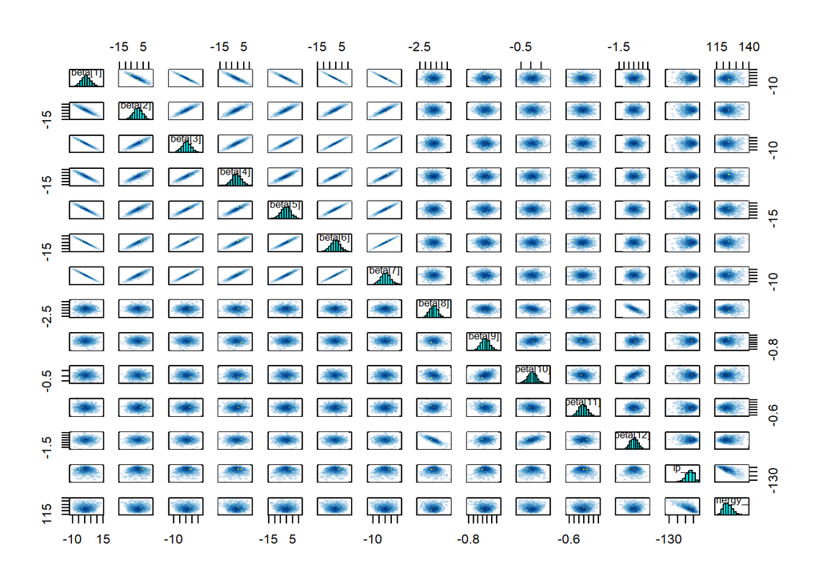

```r
#pairwise correlations
pairs(fit)
```

The autocorrelation between all beta and is:

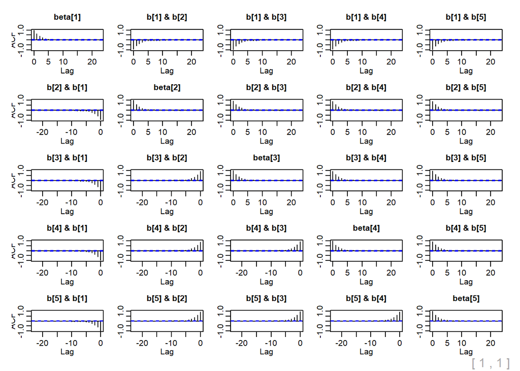

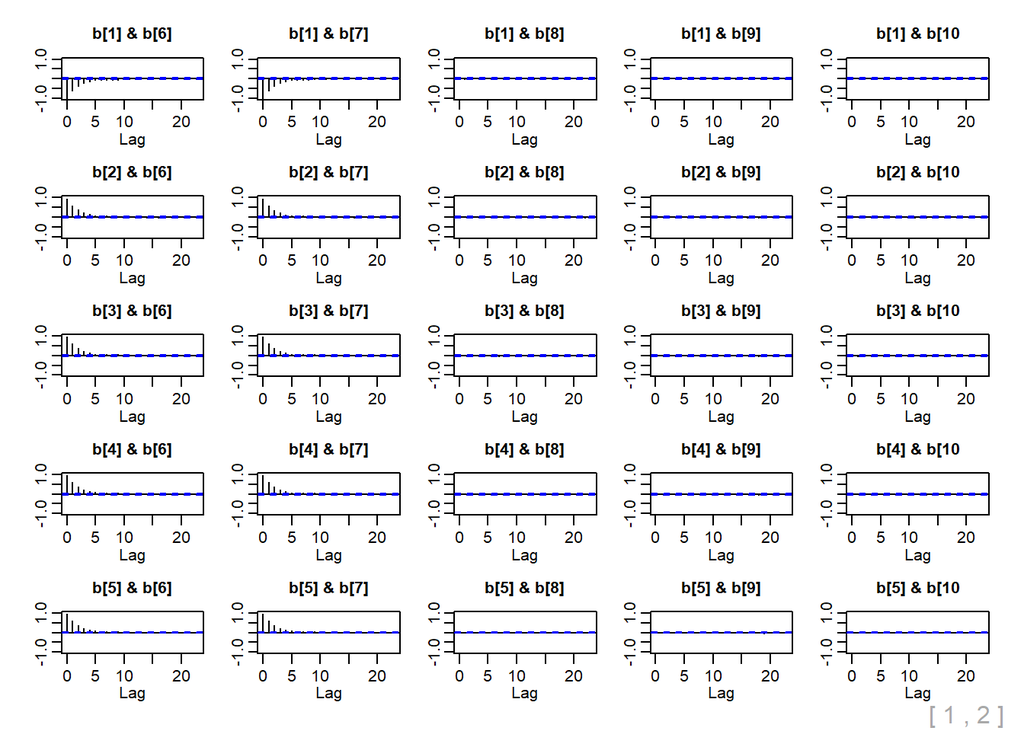

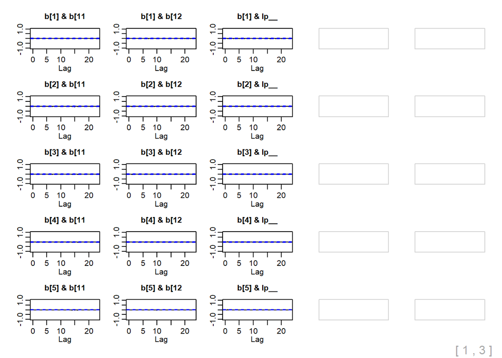

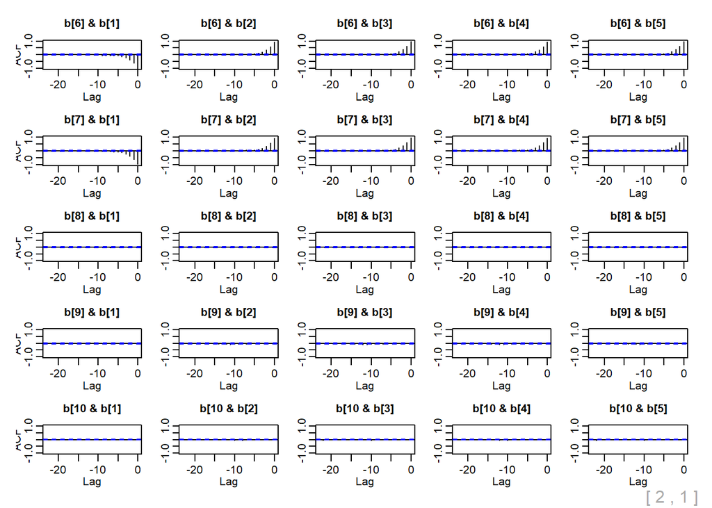

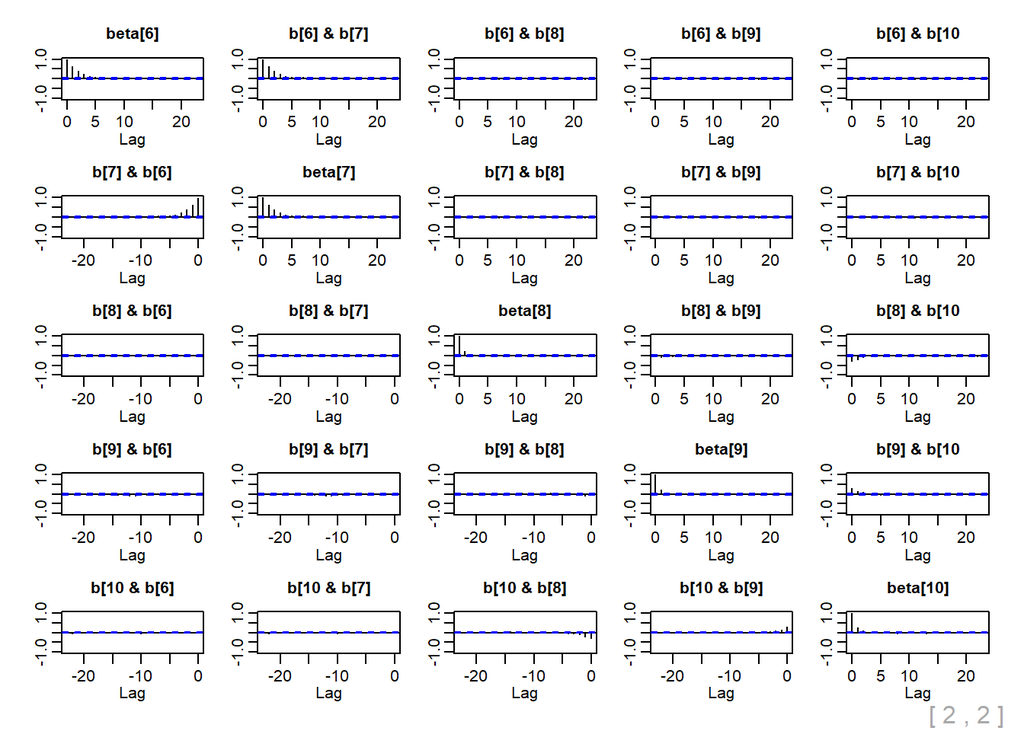

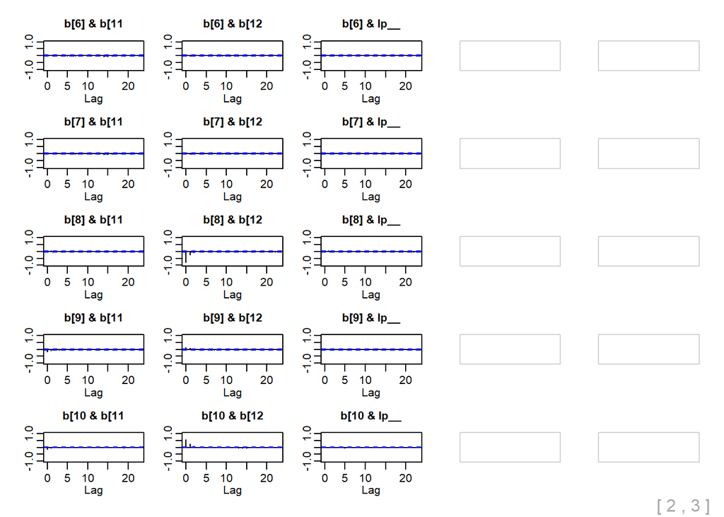

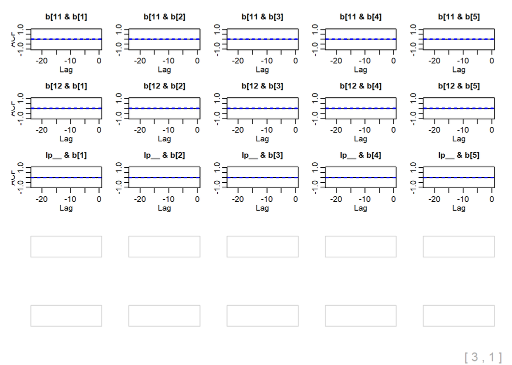

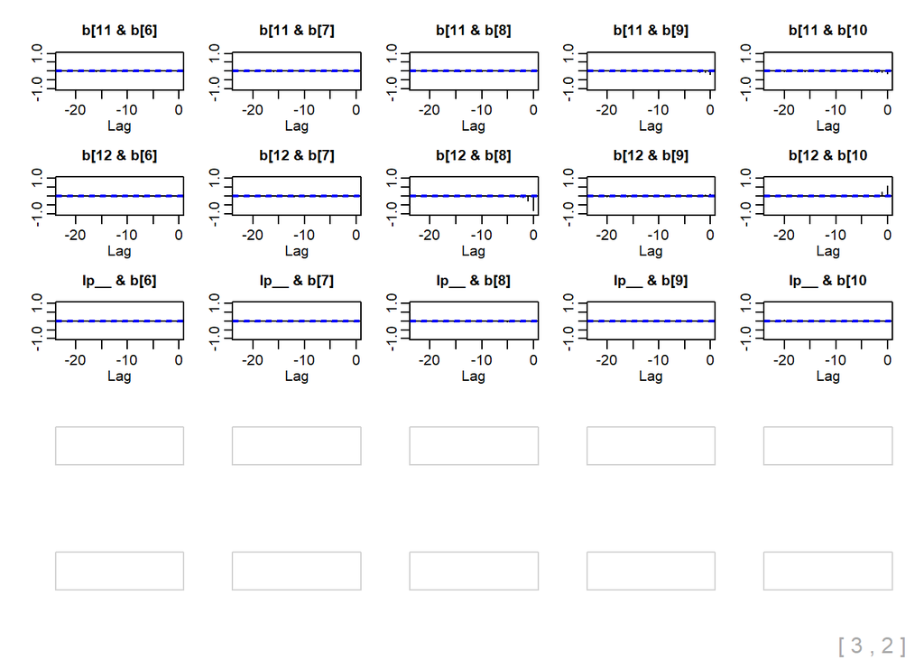

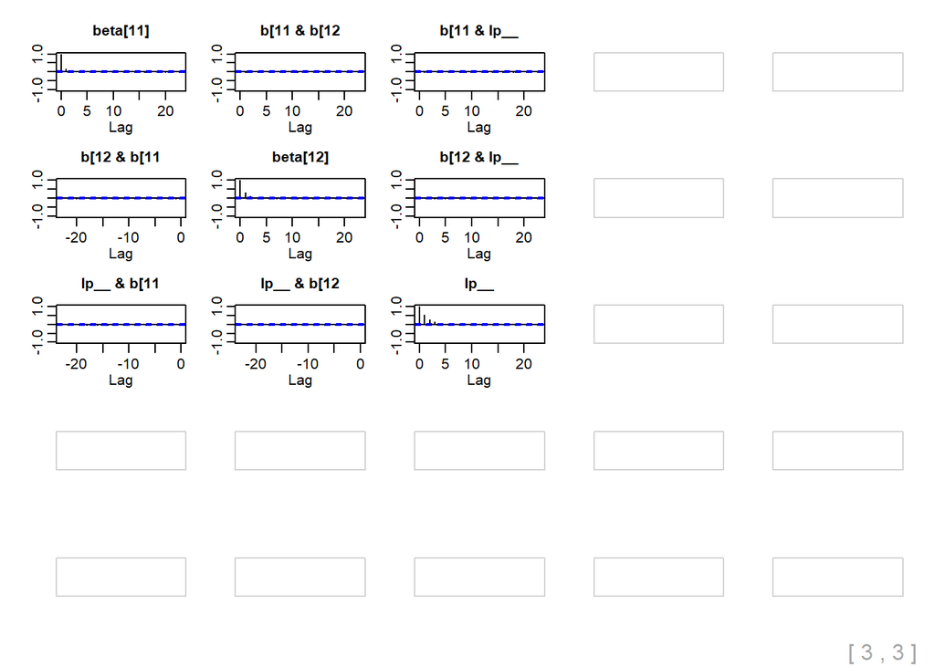

```r
acf(b)
```

Thinned paramters and theirs mean values:

```r
beta_thinned = as.matrix(beta[seq(1,800,4),])
#dim(beta_thinned)
#head(beta_thinned)
#mean estimates
means_b = colMeans(beta_thinned)
means_b
```

```
##     alpha_0     alpha_1     alpha_2     alpha_3     alpha_4     alpha_5
##  0.80721212  0.53759023  0.57329593 -0.85109410 -0.46819099 -0.42294687
##     alpha_6      beta_1      beta_2      beta_3      beta_4      beta_5
##  0.23390458 -1.24350255 -0.06374995  0.04612588 -0.05948868  0.02874725
```

## Test model accuracy

Here we make model predictions from Stan model in R. [Here](https://medium.com/@alex.pavlakis/making-predictions-from-stan-models-in-r-3e349dfac1ed) 3 ways to make predictions are described: 1. Predict outside Stan: use estimated posteriors in Stan to build the model and generate the output outside Stan, in R. 2. Predict with Stan: define only data (x_test + estimated parameters) and generated quantities (define output y_test). Model and parameter parts are empty.  
3. Fit-and-predict: except data (x_train, x_test, y_train), model (y_train) and paraeter parts I n Stan we define also y_test in generated quantities.

Here we apply the first approach. We use log regression model in R to simulate y<sub>predicted</sub>. Use MCMC parameter estimates for beta (from x,y data) and x<sub>predicted</sub> to obtain y<sub>predicted</sub>.

We first take random sample from all estimated $\beta$, all train x data, and simulate the logistic regression model in R to obtain y<sub>pred</sub>:

```r
y_pred_r <- function(x) {
  lin_comb <- rowSums(sample(beta, size = dim(x)[1], replace = TRUE)*x)
  #prob of success
  prob <- 1/(1 + exp(-lin_comb))
  #length(x) - number of observations we want to see
  # # of trials per observation = 1 = Bernoulli
  #prob - prob of success of each trial
  y_pred <- rbinom(dim(x)[1], 1, prob)
  return(y_pred)
}
```

For testing accuracy we compute how many of predicted y<sub>pred</sub>values are the same as observed y data:

```r
# Run the function on same data for x, but using r-log reg model
#and MCMC estimates for beta
set.seed(56)
y_pred_r <- y_pred_r(x)

# Accuracy
mean(y_pred_r == y)
```

```
## [1] 0.4562212
```

We repeat the same procedure for estimating the accuracy using train data, but now usng thinned $\beta$ estimates:

```r
#sum (alpha*1[i] + ... + beta1*x[i,j]+ ... beta5*x[i,12])
dim(x)
```

```
## [1] 217  12
```

```r
lin_sums<-rowSums(beta_thinned[,1:12]*x[1:200,])
#prob of success
prob_1 <- 1/(1 + exp(-lin_sums))
set.seed(123)
y_pred_1<- rbinom(dim(x)[1], 1, prob_1)
# Accuracy
mean(y_pred_1 == y)
```

```
## [1] 0.6958525
```

For analyzing the predictive properties of the model we use predicted covariates x<sub>pred</sub>to obtain the predicted output y<sub>pred</sub>.

```r
y_pred_r <- function(x) {
  lin_comb <- rowSums(sample(beta, size = dim(x)[1], replace = TRUE)*x)
  #prob of success
  prob <- 1/(1 + exp(-lin_comb))
  #length(x) - number of observations we want to see
  # # of trials per observation = 1 = Bernoulli
  #prob - prob of success of each trial
  y_pred <- rbinom(dim(x)[1], 1, prob)
  return(y_pred)
}
set.seed(56)
y_pred_r <- y_pred_r(xpred)

#prob. y_pred =0
sum(y_pred_r == 0)/length(y_pred_r) #0.516
```

```
## [1] 0.5255387
```

```r
#prob. y_pred = 1
sum(y_pred_r == 1)/length(y_pred_r) #0.483
```

```
## [1] 0.4744613
```

We can obtain the odds (probability of success) using the log regression model in R. I do not know if and how much this makes sense:

```r
mean_prob <- 0
q_lower <- 0
q_upper <- 0
prob_pred <-0

lin_comb <- rowSums(sample(beta, size = dim(x)[1], replace = TRUE)*xpred)
```

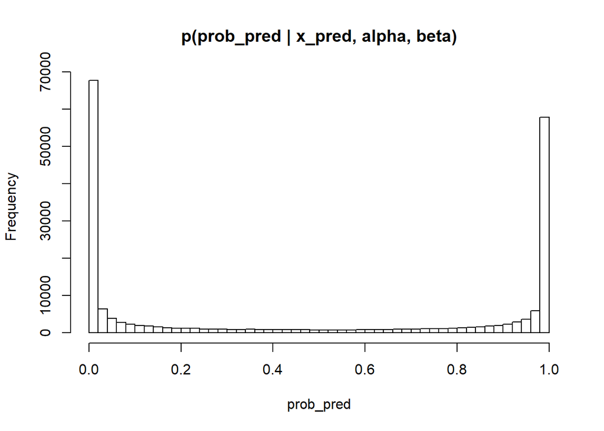

```r
for (i in 1:length(lin_comb)) {
  #prob of success
  prob_pred[i] <- 1/(1 + exp(-lin_comb[i]))
  mean_prob[i] <- mean(prob_pred[i])
  q_lower[i] <- quantile(prob_pred[i], 0.025)
  q_upper[i] <- quantile(prob_pred[i], 0.0975)
}

hist(prob_pred, main="p(prob_pred | x_pred, alpha, beta)", xlab="prob_pred",breaks=50)
```

## LOO CV for logistic regression model I repeat the same steps shown [here] (http://mc-stan.org/loo/articles/loo2-with-rstan.html) as example how to compute approximate leave-one-out cross-validation using PSIS-LOO.

In order to have access to the generated quantities in Stan, I frst have to fit the rstan model again, but without pars argument.

The new Stan model with added generated quantities is:

```stan
data {
  int<lower=1> N; //number of observations
  int<lower=1> Dx; //number of predictors + first column = intercept alpha_0
  matrix[N,Dx] x; //covariate matrix
  int<lower=0> y[N];
}

parameters {
  vector [Dx] beta;
}

model {
  //priors for alpha and beta coefficients
  //all alpha and beta coefficients are involved in beta column vector
  //beta =[alpha0, alpha1, ..., alpha6,beta1,...,beta5]
  //Set week priors for intercept and all other covariates
  for (i in 1:Dx)
    beta[i] ~ normal(0, 10);

  //the likelihood
  //y ~ bernoulli(inv_logit(x*beta)); - does not work; not stable numercally
  y ~ bernoulli_logit((x*beta));
}

//define log_lik to be usd in LOO CV
generated quantities {
  vector[N] log_lik;
  for (n in 1:N) {
    log_lik[n] = bernoulli_logit_lpmf(y[n] | x[n] * beta);
  }
}
```

Fit the model in R:

```r
fit1 <- stan(file = "Log_reg_whitefish.stan", data = whitefish_dat, warmup=300,
            iter = 1100, init=inits , control = list(adapt_delta = 0.99))
```

Provide leave-one-out cross validation:

```r
library(loo)
# Extract pointwise log-likelihood
# using merge_chains=FALSE returns an array, which is easier to
# use with relative_eff()
log_lik <- extract_log_lik(fit1, parameter_name = "log_lik", merge_chains = FALSE)

# as of loo v2.0.0 we can optionally provide relative effective sample sizes
# when calling loo, which allows for better estimates of the PSIS effective
# sample sizes and Monte Carlo error
r_eff <- relative_eff(exp(log_lik), cores = 2)

# preferably use more than 2 cores (as many cores as possible)
# will use value of 'mc.cores' option if cores is not specified
loo_1 <- loo(log_lik, r_eff = r_eff, cores = 2)
print(loo_1)
```

```
##
## Computed from 3200 by 217 log-likelihood matrix
##
##          Estimate   SE
## elpd_loo   -125.0  8.9
## p_loo        13.6  2.2
## looic       250.0 17.9
## ------
## Monte Carlo SE of elpd_loo is NA.
##
## Pareto k diagnostic values:
##                          Count Pct.    Min. n_eff
## (-Inf, 0.5]   (good)     213   98.2%   1280
##  (0.5, 0.7]   (ok)         3    1.4%   328
##    (0.7, 1]   (bad)        0    0.0%   <NA>
##    (1, Inf)   (very bad)   1    0.5%   61
## See help('pareto-k-diagnostic') for details.
```

The explanation about the LOO CV results:

The printed output from the loo function shows the estimates elpd<sub>loo</sub> (expected log predictive density), p<sub>loo</sub> (effective number of parameters), and looic=−2elpd<sub>loo</sub> (the LOO information criterion).

The loo package is useful also for model comparison.

K-fold cross validation could be provided in R, without using STAN.

Next:

- making predictions: what they should be?
- visualize the predictions.